# Biostat 203B Homework 4

Due Mar 12 @ 11:59PM

Load database libraries and the tidyverse frontend:

## Q1. Missing data

Through the Shiny app developed in HW3, we observe abundant missing values in the MIMIC-IV ICU cohort we created. In this question, we use multiple imputation to obtain a data set without missing values.

0. Read following tutorials on the R package miceRanger for imputation: https://github.com/farrellday/miceRanger, https://cran.r-project.org/web/packages/miceRanger/vignettes/miceAlgorithm.html.

   A more thorough book treatment of the practical imputation strategies is the book [*Flexible Imputation of Missing Data*](https://stefvanbuuren.name/fimd/) by Stef van Buuren.
1. Explain the jargon MCAR, MAR, and MNAR.

**Solution**:

MCAR stands for Missing Completely At Random. A variable is missing completely at random if neither the variables in the dataset nor the unobserved value of the variable itself predict whether a value will be missing. In other words, the causes of missing data are unrelated to the data.

MAR stands for Missing at Random. A variable is missing at random if other variables in the dataset can be used to predict the missingness of the variable. In other words, the probability of missingness is the same only within groups defined by the observed data. Most modern missing data methods start from the MAR assumption.

MNAR stands for Missing Not at Random. A variable is missing not at random if the value of the unobserved variable itself predicts missingness. MNAR is the most complex case as the causes for the missingness vary for reasons unknown to the investigator.

2. Explain in a couple of sentences how the Multiple Imputation by Chained Equations (MICE) work.

**Solution**:

Multiple Imputation by Chained Equations (MICE) works by creating multiple imputations to account for statistical uncertainty in the imputations, and utilizing a chained equations approach to allow for flexibility with handling variables of different types. Using the MICE technique assumes that for the variables used in the imputation procedure, the missing data are MAR. If this assumption is not met, then there could be biased estimates when MICE is implemented.

The chained equation process involves 1) an imputation performed for every missing value in the data set, 2) placeholder imputations for one variable are set back to missing, 3) observed values from that one variable are regressed on other variables in the data set, with the one variable as the outcome variable, 4) missing values for that one variable are replaced with the imputations from the regression model if it is used as an outcome, and both observed and imputed values will be used if the variable is used as a predictor. The process is repeated for all the variables to complete one iteration/cycle. For later cycles, imputations are updated at each subsequent cycle. The accuracy of the imputations depends on the information density in the dataset. A dataset of completely independent variables with no correlation will not yield accurate imputations.

3. Perform a data quality check of the ICU stays data. Discard variables with substantial missingness, say >5000 `NA`s. Replace apparent data entry errors by `NA`s.

**Solution**:

```r
icu_cohort <- readRDS("./icu_cohort.rds")

sapply(icu_cohort, function(x) sum(is.na(x)))
```

```
##                           subject_id                              hadm_id
##                                    0                                    0
##                              stay_id                       first_careunit
##                                    0                                    0
##                        last_careunit                               intime
##                                    0                                    0
##                              outtime                                  los
##                                    0                                    0
##                            admittime                            dischtime
##                                    0                                    0
##                            deathtime                       admission_type
##                                44872                                    0
##                   admission_location                   discharge_location
##                                    0                                  452
##                            insurance                             language
##                                    0                                    0
##                       marital_status                            ethnicity
##                                 4176                                    0
##                            edregtime                            edouttime
##                                18462                                18462
##                 hospital_expire_flag                               gender
##                                    0                                    0
##                           anchor_age                          anchor_year
##                                    0                                    0
##                    anchor_year_group                                  dod
##                                    0                                50048
##                             admitage                           heart_rate
##                                    0                                    8
## non_invasive_blood_pressure_systolic     non_invasive_blood_pressure_mean
##                                  572                                  593
##                     respiratory_rate               temperature_fahrenheit
##                                   34                                  827
##     arterial_blood_pressure_systolic         arterial_blood_pressure_mean
##                                29019                                28897
##                          bicarbonate                              calcium
##                                  861                                 2374
##                             chloride                           creatinine
##                                  835                                  839
##                              glucose                            magnesium
##                                  850                                 1017
##                            potassium                               sodium
##                                  852                                  826
##                           hematocrit                                  wbc
##                                 1016                                 1032
##                              lactate                          mortality30
##                                19843                                    0
```

```r
# discarding variables with substantial missingness
icu_cohort2 <- icu_cohort %>%
  dplyr::select(-deathtime, -edregtime, -edouttime, -dod,
         -arterial_blood_pressure_systolic, -arterial_blood_pressure_mean,
         -lactate)
```

I utilized sapply to identify missing values and distribution of values in the dataset. This allowed to identify patients with abnormal values such as a heart rate of 0 when the patient survived and had normal bp measurements for the other columns. I re-ran these built-in functions as necessary to identify data entry errors and filtered them out in the subsequent code chunk.

```r
sapply(icu_cohort2[,4:5], unique)
sapply(icu_cohort2[,11:19], unique)
sapply(icu_cohort2[,24:38], unique)
sapply(icu_cohort2[,24:38], summary)
```

Here, I filter out apparent data entry errors. I remained fairly conservative in my removal of abnormal data values, and primarily focused on 0s in the data when other columns appeared to have normal values, and also focused on possible scale conversion errors with Fahrenheit/Celsius that may have been recorded under the Fahrenheit column of the original data set.

```r
# replace 0s with NAs for heart rate, non invasive bp (systolic and mean),
# respiratory rate, temperature in Fahrenheit
icu_cohort2[, 24:28][icu_cohort2[, 24:28] == 0] = NA

# replace 0s with NAs for calcium, creatinine, magnesium, and wbc
icu_cohort2$calcium[icu_cohort2$calcium == 0] = NA
icu_cohort2$creatinine[icu_cohort2$creatinine == 0] = NA
icu_cohort2$magnesium[icu_cohort2$magnesium == 0] = NA
icu_cohort2$wbc[icu_cohort2$wbc == 0] = NA


# replace with NA if blood pressure values were less than 2
icu_cohort2[, 25:26][icu_cohort2[, 25:26] < 2] = NA

# replace with NA if blood pressure values were substantially abnormal
icu_cohort2 <- icu_cohort2 %>%
  mutate(non_invasive_blood_pressure_systolic = ifelse(
      (non_invasive_blood_pressure_systolic > 300) |
        (non_invasive_blood_pressure_systolic < 10), NA,
      non_invasive_blood_pressure_systolic),
    non_invasive_blood_pressure_mean = ifelse(
      non_invasive_blood_pressure_mean > 300 |
        (non_invasive_blood_pressure_mean < 10), NA,
      non_invasive_blood_pressure_mean),
    # replace with NA if heart rate values were substantially abnormal
    heart_rate = ifelse(heart_rate > 300, NA, heart_rate)
  )


# replace with NA if temperature in Fahrenheit was less than 60
icu_cohort2$temperature_fahrenheit[icu_cohort2$temperature_fahrenheit < 60] = NA

# Check NAs
sapply(icu_cohort2, function(x) sum(is.na(x)))
```

```
##                           subject_id                              hadm_id
##                                    0                                    0
##                              stay_id                       first_careunit
##                                    0                                    0
##                        last_careunit                               intime
##                                    0                                    0
##                              outtime                                  los
##                                    0                                    0
##                            admittime                            dischtime
##                                    0                                    0
##                       admission_type                   admission_location
##                                    0                                    0
##                   discharge_location                            insurance
##                                  452                                    0
##                             language                       marital_status
##                                    0                                 4176
##                            ethnicity                 hospital_expire_flag
##                                    0                                    0
##                               gender                           anchor_age
##                                    0                                    0
##                          anchor_year                    anchor_year_group
##                                    0                                    0
##                             admitage                           heart_rate
##                                    0                                   18
## non_invasive_blood_pressure_systolic     non_invasive_blood_pressure_mean
##                                  578                                  605
##                     respiratory_rate               temperature_fahrenheit
##                                  168                                  924
##                          bicarbonate                              calcium
##                                  861                                 2378
##                             chloride                           creatinine
##                                  835                                  842
##                              glucose                            magnesium
##                                  850                                 1018
##                            potassium                               sodium
##                                  852                                  826
##                           hematocrit                                  wbc
##                                 1016                                 1033
##                          mortality30
##                                    0
```

4. Impute missing values by `miceRanger` (request $m=3$ datasets). This step is very computational intensive. Make sure to save the imputation results as a file.

**Solution**:

No variables were dropped for completeness and out of caution. In order to maximize reproducibility and efficiency, the code for `miceRanger` was wrapped in a conditional statement so that the imputation does not have to be rerun when knitting the code repeatedly. The chunk was wrapped using the chunk option `cache.lazy = FALSE` to help the miceObj load more quickly.

Credit to Benson Wu @benson-wu for troubleshooting this code for me.

```r
if(file.exists(str_c("./miceObj.RData"))){
  load(str_c("./miceObj.RData"))
} else{
  miceObj <- miceRanger(
    icu_cohort2, m = 3, max.depth = 10, returnModels = T, verbose = F
                         )
  save(miceObj, file = "./miceObj.RData")
}
```

5. Make imputation diagnostic plots and explain what they mean.

**Solution**:

The plot below generated by `plotDistributions()` is a plot of the imputed distributions compared to the original distribution for each numeric variable in the dataset. The red line is the density of the original, non-missing data, and the black lines are the density of the imputed values in each of the 3 datasets. We can see that the distributions of the non-missing data and the imputed values in the 3 datasets match up closely for the variables respiratory rate, temperature (F), calcium, chloride, creatinine, glucose, magnesium, potassium, sodium, hematocrit, and wbc (white blood cell count). The distributions of the non-missing data and imputed values in the 3 data sets do not match up very closely for heart rate, non-invasive systolic blood pressure, non-invasive mean blood pressure, and bicarbonate. The distributions of non-missing and imputed values not matching up may imply that for those variables the data was not missing completely at random (MCAR).

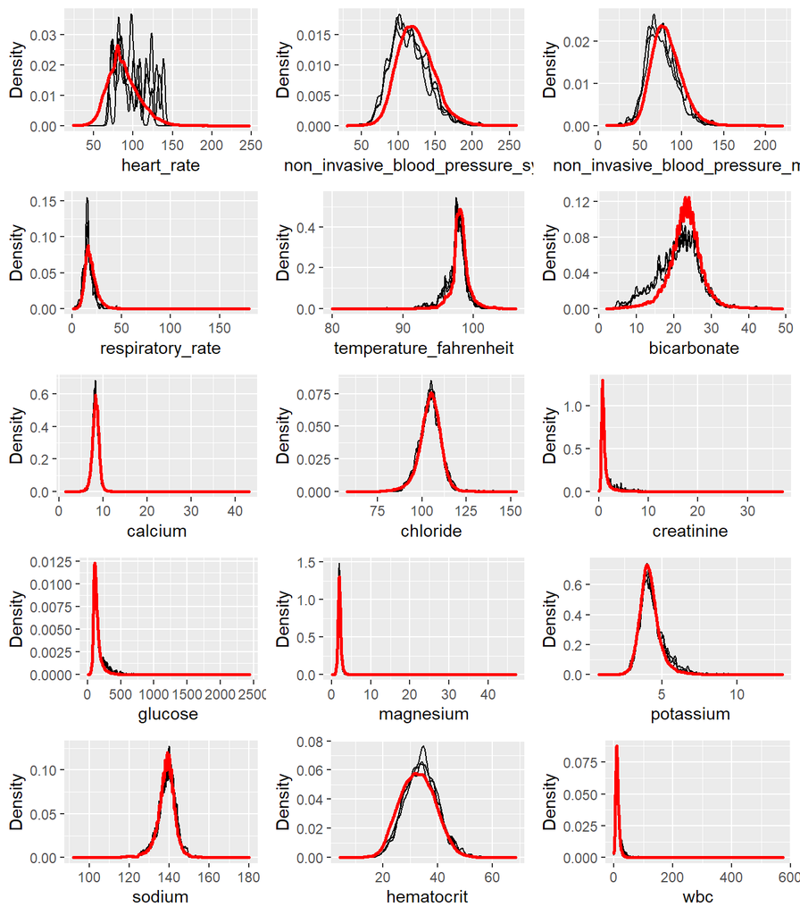

```r
plotDistributions(miceObj, vars = 'allNumeric', ncol = 3, nrow = 5)
```

The boxplots below are boxplots of the correlations between imputed values in every combination of datasets at each iteration. This tells us how values between datasets converged over the iterations.

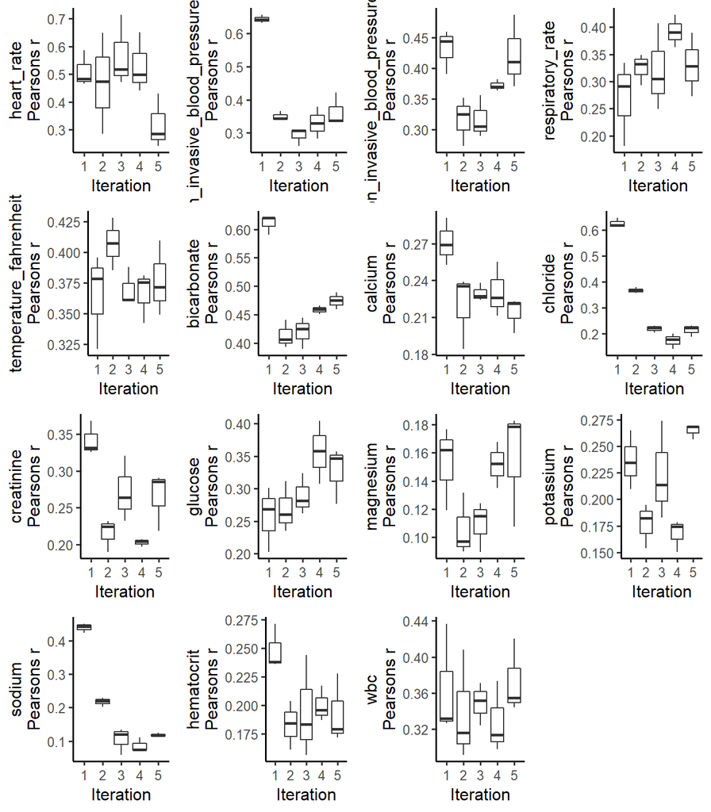

```r
plotCorrelations(miceObj, vars = 'allNumeric')
```

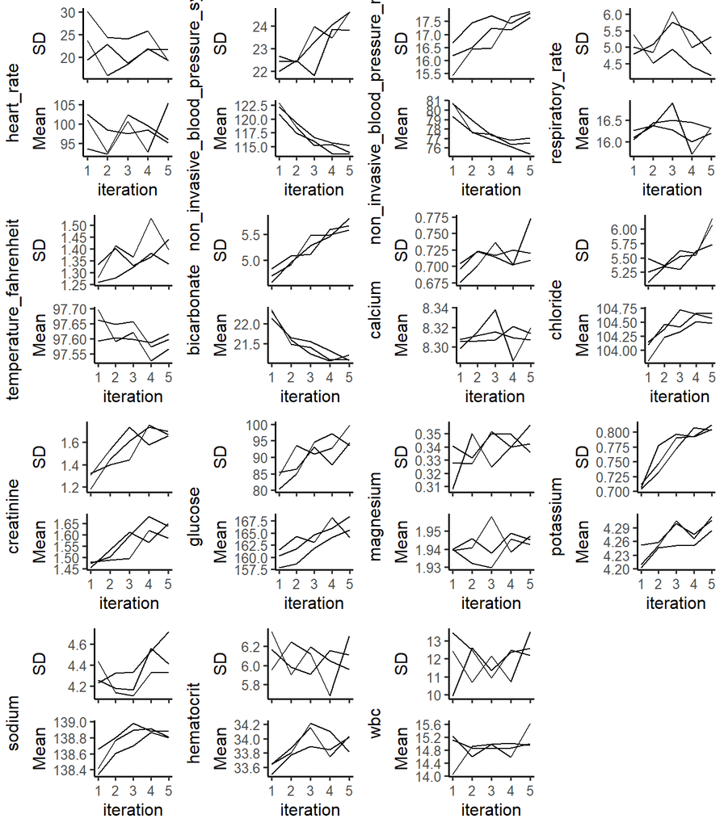

```r
plotVarConvergence(miceObj, vars = 'allNumeric')
```

Below the plots returns the OOB R<sup>2</sup> for regression for each dataset and each iteration. We see that variables were not necessarily imputed with a reasonable degree of accuracy, since the R<sup>2</sup> does not converge with a high degree of accuracy even towards the later iterations for many of the numeric variables.